# Project 1

## Summary

Using the mtcars data set in R, a data set of a collection of cars, this analysis explores the relationship between a set of variables and miles per gallon (MPG) (outcome). We seek to answer the following questions:

- “Is an automatic or manual transmission better for MPG”
- “Quantify the MPG difference between automatic and manual transmissions”

### Part 1: Is an automatic or manual transmission better for MPG?

First, let’s examine the data and relevel the factor variables.

```r
data(mtcars)
head(mtcars)
```

|  | mpg | cyl | disp | hp | drat | wt | qsec | vs | am | gear | carb |
| --- | --- | --- | --- | --- | --- | --- | --- | --- | --- | --- | --- |
| Mazda RX4 | 21.0 | 6 | 160 | 110 | 3.90 | 2.620 | 16.46 | 0 | 1 | 4 | 4 |
| Mazda RX4 Wag | 21.0 | 6 | 160 | 110 | 3.90 | 2.875 | 17.02 | 0 | 1 | 4 | 4 |
| Datsun 710 | 22.8 | 4 | 108 | 93 | 3.85 | 2.320 | 18.61 | 1 | 1 | 4 | 1 |
| Hornet 4 Drive | 21.4 | 6 | 258 | 110 | 3.08 | 3.215 | 19.44 | 1 | 0 | 3 | 1 |
| Hornet Sportabout | 18.7 | 8 | 360 | 175 | 3.15 | 3.440 | 17.02 | 0 | 0 | 3 | 2 |
| Valiant | 18.1 | 6 | 225 | 105 | 2.76 | 3.460 | 20.22 | 1 | 0 | 3 | 1 |

```r
mtcars$cyl<-relevel(as.factor(mtcars$cyl), ref='8')
mtcars$vs<-relevel(as.factor(mtcars$vs), ref='0')
mtcars$am<-relevel(as.factor(mtcars$am), ref='0',labels=c('Automatic','Manual'))
mtcars$gear<-relevel(as.factor(mtcars$gear), ref='3')
mtcars$carb<-relevel(as.factor(mtcars$carb), ref='2')
```

Now, model mpg and transmission using a 2-variable linear model.

```r
lm1 <- lm(mpg~am,data=mtcars)
summary(lm1)
```

```
##
## Call:
## lm(formula = mpg ~ am, data = mtcars)
##
## Residuals:
##     Min      1Q  Median      3Q     Max
## -9.3923 -3.0923 -0.2974  3.2439  9.5077
##
## Coefficients:
##             Estimate Std. Error t value Pr(>|t|)
## (Intercept)   17.147      1.125  15.247 1.13e-15 ***
## am1            7.245      1.764   4.106 0.000285 ***
## ---
## Signif. codes:  0 '***' 0.001 '**' 0.01 '*' 0.05 '.' 0.1 ' ' 1
##
## Residual standard error: 4.902 on 30 degrees of freedom
## Multiple R-squared:  0.3598, Adjusted R-squared:  0.3385
## F-statistic: 16.86 on 1 and 30 DF,  p-value: 0.000285
```

From the data, we know ‘am’, aka transmission, is a binary variable with automatic equal to 0 and manual equal to 1. Based on the output, we can see that the average mpg for automatic is 17.147, whereas for manual it is 24.392

Now, let’s fit a regression model including all variables.

```r
lm2 <- lm(mpg~.,mtcars)
summary(lm2)
```

```
##
## Call:
## lm(formula = mpg ~ ., data = mtcars)
##
## Residuals:
##     Min      1Q  Median      3Q     Max
## -3.5087 -1.3584 -0.0948  0.7745  4.6251
##
## Coefficients:
##             Estimate Std. Error t value Pr(>|t|)
## (Intercept) 22.56362   17.74315   1.272   0.2229
## cyl4         0.33616    7.15954   0.047   0.9632
## cyl6        -2.31253    5.49944  -0.421   0.6801
## disp         0.03555    0.03190   1.114   0.2827
## hp          -0.07051    0.03943  -1.788   0.0939 .
## drat         1.18283    2.48348   0.476   0.6407
## wt          -4.52978    2.53875  -1.784   0.0946 .
## qsec         0.36784    0.93540   0.393   0.6997
## vs1          1.93085    2.87126   0.672   0.5115
## am1          1.21212    3.21355   0.377   0.7113
## gear4        1.11435    3.79952   0.293   0.7733
## gear5        2.52840    3.73636   0.677   0.5089
## carb1        0.97935    2.31797   0.423   0.6787
## carb3        3.97899    3.85764   1.031   0.3187
## carb4        2.07078    3.49316   0.593   0.5621
## carb6        5.45692    5.82857   0.936   0.3640
## carb8        8.22977    7.84852   1.049   0.3110
## ---
## Signif. codes:  0 '***' 0.001 '**' 0.01 '*' 0.05 '.' 0.1 ' ' 1
##
## Residual standard error: 2.833 on 15 degrees of freedom
## Multiple R-squared:  0.8931, Adjusted R-squared:  0.779
## F-statistic:  7.83 on 16 and 15 DF,  p-value: 0.000124
```

From the output, we can see the adjusted R-squared indicates that some variables are included that are not important. In addition, all variables in this model are insignificant.

```r
vif(lm2)
```

```
##            GVIF Df GVIF^(1/(2*Df))
## cyl  128.120962  2        3.364380
## disp  60.365687  1        7.769536
## hp    28.219577  1        5.312210
## drat   6.809663  1        2.609533
## wt    23.830830  1        4.881683
## qsec  10.790189  1        3.284842
## vs     8.088166  1        2.843970
## am     9.930495  1        3.151269
## gear  50.852311  2        2.670408
## carb 503.211851  5        1.862838
```

```r
lm3$coefficients
```

```
## (Intercept)        cyl4        cyl6          hp          wt         am1
## 31.54464858  2.16367532 -0.86766917 -0.03210943 -2.49682942  1.80921138
```

```r
summary(lm3)$adj.r.squared
```

```
## [1] 0.8400875
```

```r
anova(lm1,lm2,lm3)
```

|  | Res.Df | RSS | Df | Sum of Sq | F | Pr(>F) |
| --- | --- | --- | --- | --- | --- | --- |
| 1 | 30 | 720.8966 | NA | NA | NA | NA |
| 2 | 15 | 120.4027 | 15 | 600.49393 | 4.9873804 | 0.001758505 |
| 3 | 26 | 151.0256 | -11 | -30.62292 | 0.3468239 | 0.958824199 |

The `anova` output verifies that the 3rd model, `lm3`, is the most adequate.

After performing diagnostic plots of the residuals, **Figure 2** shows that the residuals appear to have mean of 0, but not constant variance.  
**Figure 3** indicates that the residuals do not completely follow normal distribution. Therefore, the model is not perfect.

However, from the different models tested, the data indicates that manual transmission may be better for MPG rather than automatic.

### Part 2: Quantify the MPG difference between automatic and manual transmissions

First, we look back at the `lm1` model to see the slope of the `am` variable, which quantifies the difference between automatic and manual transmissions.

```r
summary(lm1)
```

```
##
## Call:
## lm(formula = mpg ~ am, data = mtcars)
##
## Residuals:
##     Min      1Q  Median      3Q     Max
## -9.3923 -3.0923 -0.2974  3.2439  9.5077
##
## Coefficients:
##             Estimate Std. Error t value Pr(>|t|)
## (Intercept)   17.147      1.125  15.247 1.13e-15 ***
## am1            7.245      1.764   4.106 0.000285 ***
## ---
## Signif. codes:  0 '***' 0.001 '**' 0.01 '*' 0.05 '.' 0.1 ' ' 1
##
## Residual standard error: 4.902 on 30 degrees of freedom
## Multiple R-squared:  0.3598, Adjusted R-squared:  0.3385
## F-statistic: 16.86 on 1 and 30 DF,  p-value: 0.000285
```

We can see that without any other variables, manual transmission cars get about 7.245 more miles per gallon than automatic transmission cars.

```r
summary(lm3)
```

```
##
## Call:
## lm(formula = mpg ~ cyl + hp + wt + am, data = mtcars)
##
## Residuals:
##     Min      1Q  Median      3Q     Max
## -3.9387 -1.2560 -0.4013  1.1253  5.0513
##
## Coefficients:
##             Estimate Std. Error t value Pr(>|t|)
## (Intercept) 31.54465    3.88461   8.120 1.34e-08 ***
## cyl4         2.16368    2.28425   0.947  0.35225
## cyl6        -0.86767    1.71921  -0.505  0.61803
## hp          -0.03211    0.01369  -2.345  0.02693 *
## wt          -2.49683    0.88559  -2.819  0.00908 **
## am1          1.80921    1.39630   1.296  0.20646
## ---
## Signif. codes:  0 '***' 0.001 '**' 0.01 '*' 0.05 '.' 0.1 ' ' 1
##
## Residual standard error: 2.41 on 26 degrees of freedom
## Multiple R-squared:  0.8659, Adjusted R-squared:  0.8401
## F-statistic: 33.57 on 5 and 26 DF,  p-value: 1.506e-10
```

With all other factors held constant, manual transmission cars get about 1.809 more miles per gallon than automatic transmission cars.

# Appendix

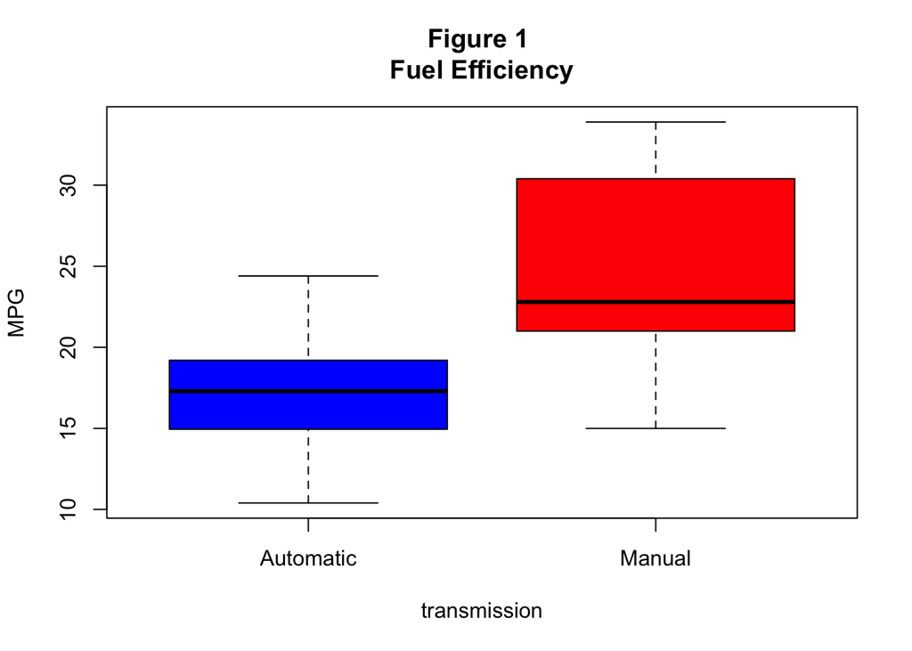

```r
boxplot(mpg~am, data=mtcars, main ='Figure 1 \nFuel Efficiency',ylab='MPG', xlab="transmission",names=c("Automatic","Manual"),notch=FALSE, col=(c("blue","red")))
```

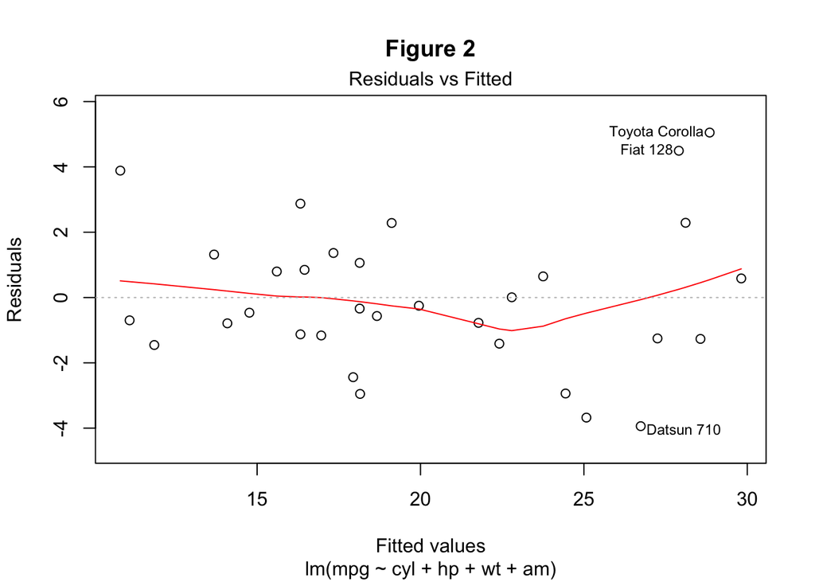

```r
plot(lm3,which=1,main="Figure 2")
```

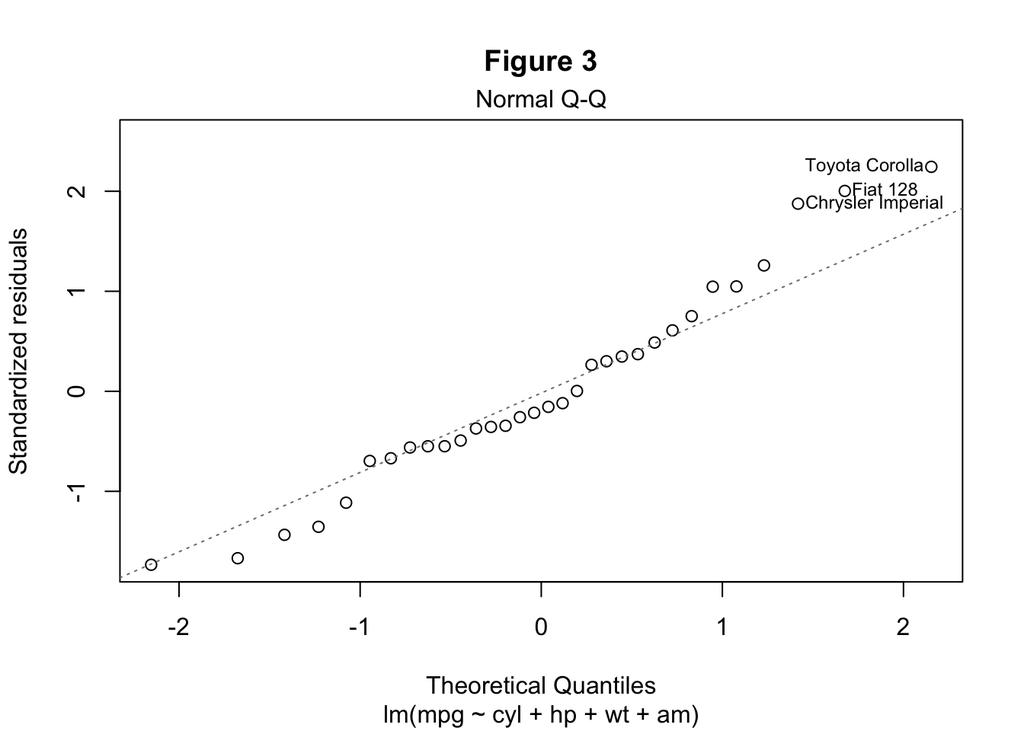

```r
plot(lm3,which=2,main="Figure 3")
```